# Machine Learning Project

Jorgevillamizarco

Thursday, September 20, 2014

## Executive summary

The purpose of the present document is to analyze data captured by Groupware for HAR (Human Activity Recognition) experiments and propose a machine learning algorithm for “classe” variable prediction. Prediction model will be tested with 20 scenarios.

## Getting and Cleaning Data

First we need to download all necessary data and load it removing all missing values using the following code lines:

```r
traindata <- read.table("./pml-training.csv", sep=",", na.strings = c("", "NA", "#DIV/0!"), header=TRUE)
testdata <- read.table("./pml-testing.csv", sep=",", na.strings = c("", "NA", "#DIV/0!"), header=TRUE)
```

traingdata dataset will be used for model creation, training, error calculation and model validation, while testdata dataset will be used for prediction. With a first look over traindata we can see that theres a lot of variables with missing values, so in order to get a simpler dataset its necessary to remove those variables, first calculating the number of NAs for each column and then removing all columns with 90% or more of NAs:

```r
nas <- apply(traindata, 2, function(x) sum(is.na(x)))
nas < 0.9*nrow(traindata)
```

```
##                        X                user_name     raw_timestamp_part_1
##                     TRUE                     TRUE                     TRUE
##     raw_timestamp_part_2           cvtd_timestamp               new_window
##                     TRUE                     TRUE                     TRUE
##               num_window                roll_belt               pitch_belt
##                     TRUE                     TRUE                     TRUE
##                 yaw_belt         total_accel_belt       kurtosis_roll_belt
##                     TRUE                     TRUE                    FALSE
##      kurtosis_picth_belt        kurtosis_yaw_belt       skewness_roll_belt
##                    FALSE                    FALSE                    FALSE
##     skewness_roll_belt.1        skewness_yaw_belt            max_roll_belt
##                    FALSE                    FALSE                    FALSE
##           max_picth_belt             max_yaw_belt            min_roll_belt
##                    FALSE                    FALSE                    FALSE
##           min_pitch_belt             min_yaw_belt      amplitude_roll_belt
##                    FALSE                    FALSE                    FALSE
##     amplitude_pitch_belt       amplitude_yaw_belt     var_total_accel_belt
##                    FALSE                    FALSE                    FALSE
##            avg_roll_belt         stddev_roll_belt            var_roll_belt
##                    FALSE                    FALSE                    FALSE
##           avg_pitch_belt        stddev_pitch_belt           var_pitch_belt
##                    FALSE                    FALSE                    FALSE
##             avg_yaw_belt          stddev_yaw_belt             var_yaw_belt
##                    FALSE                    FALSE                    FALSE
##             gyros_belt_x             gyros_belt_y             gyros_belt_z
##                     TRUE                     TRUE                     TRUE
##             accel_belt_x             accel_belt_y             accel_belt_z
##                     TRUE                     TRUE                     TRUE
##            magnet_belt_x            magnet_belt_y            magnet_belt_z
##                     TRUE                     TRUE                     TRUE
##                 roll_arm                pitch_arm                  yaw_arm
##                     TRUE                     TRUE                     TRUE
##          total_accel_arm            var_accel_arm             avg_roll_arm
##                     TRUE                    FALSE                    FALSE
##          stddev_roll_arm             var_roll_arm            avg_pitch_arm
##                    FALSE                    FALSE                    FALSE
##         stddev_pitch_arm            var_pitch_arm              avg_yaw_arm
##                    FALSE                    FALSE                    FALSE
##           stddev_yaw_arm              var_yaw_arm              gyros_arm_x
##                    FALSE                    FALSE                     TRUE
```

[output cut: 53 more lines]

```
##                    FALSE                     TRUE                    FALSE
##         avg_roll_forearm      stddev_roll_forearm         var_roll_forearm
##                    FALSE                    FALSE                    FALSE
##        avg_pitch_forearm     stddev_pitch_forearm        var_pitch_forearm
##                    FALSE                    FALSE                    FALSE
##          avg_yaw_forearm       stddev_yaw_forearm          var_yaw_forearm
##                    FALSE                    FALSE                    FALSE
##          gyros_forearm_x          gyros_forearm_y          gyros_forearm_z
##                     TRUE                     TRUE                     TRUE
##          accel_forearm_x          accel_forearm_y          accel_forearm_z
##                     TRUE                     TRUE                     TRUE
##         magnet_forearm_x         magnet_forearm_y         magnet_forearm_z
##                     TRUE                     TRUE                     TRUE
##                   classe
##                     TRUE
```

```r
traindata <- traindata[,(nas < 0.9*nrow(traindata))]
```

```r
traindata <- traindata[, 8:dim(traindata)[2]]
traindata$classe <- as.factor(traindata$classe)
```

For testdata dataset its necessary to remove all variables that were removed from traindata dataset because for next steps well need those two dataset with equal lengths:

```r
defcols <- names(traindata)
testdata <- testdata[, (colnames(testdata) %in% defcols)]
```

## Model Creation

In this step, we are going to create, train, test and calculate errors, so first we need to subset traindata into training (train variable) and testing (test variable) sets for posterior cross-validation:

```r
library(caret)
library(randomForest)
trainingIndex  <- createDataPartition(traindata$classe, p=.60, list=FALSE)
train <- traindata[ trainingIndex,]
test  <- traindata[-trainingIndex,]
```

```r
set.seed(10)
model <- randomForest(train[,-53], train$classe, ntree=100, nodesize=10, importance=T)
```

Predict and confusionMatrix functions are used to test model and obtain cross-validation results. Prediction result is assigned to “pred” variable, then this one is used in confusionMatrix function to obtain the sample error:

```r
pred <- predict(model, test)
confusionMatrix(pred,test$classe)
```

```
## Confusion Matrix and Statistics
##
##           Reference
## Prediction    A    B    C    D    E
##          A 2227   12    0    0    0
##          B    0 1500   18    0    0
##          C    3    6 1345   25    0
##          D    0    0    5 1259    7
##          E    2    0    0    2 1435
##
## Overall Statistics
##
##                Accuracy : 0.99
##                  95% CI : (0.987, 0.992)
##     No Information Rate : 0.284
##     P-Value [Acc > NIR] : <2e-16
##
##                   Kappa : 0.987
##  Mcnemar's Test P-Value : NA
##
## Statistics by Class:
##
##                      Class: A Class: B Class: C Class: D Class: E
## Sensitivity             0.998    0.988    0.983    0.979    0.995
## Specificity             0.998    0.997    0.995    0.998    0.999
## Pos Pred Value          0.995    0.988    0.975    0.991    0.997
## Neg Pred Value          0.999    0.997    0.996    0.996    0.999
## Prevalence              0.284    0.193    0.174    0.164    0.184
## Detection Rate          0.284    0.191    0.171    0.160    0.183
## Detection Prevalence    0.285    0.193    0.176    0.162    0.183
## Balanced Accuracy       0.998    0.993    0.989    0.989    0.997
```

```r
sort(importance(model)[,1], decreasing=T)
```

```
##             yaw_belt    magnet_dumbbell_z    magnet_dumbbell_y
##               19.841               18.790               16.033
##            roll_belt         roll_forearm        pitch_forearm
##               15.720               14.435               14.286
##     magnet_forearm_z           pitch_belt     accel_dumbbell_y
##               13.022               13.006               12.689
##    magnet_dumbbell_x          yaw_forearm        roll_dumbbell
##               10.884               10.413               10.372
##         magnet_arm_z     magnet_forearm_y     gyros_dumbbell_y
##               10.152                9.695                9.199
##         gyros_belt_z      accel_forearm_z             roll_arm
##                9.018                8.791                8.673
##        magnet_belt_z      gyros_forearm_y        magnet_belt_x
##                8.417                8.266                8.264
##         accel_belt_z        magnet_belt_y total_accel_dumbbell
##                8.155                8.154                8.065
##         yaw_dumbbell     gyros_dumbbell_x      accel_forearm_y
##                8.052                8.009                7.821
##            pitch_arm     magnet_forearm_x          accel_arm_y
##                7.817                7.791                7.753
##         magnet_arm_x  total_accel_forearm              yaw_arm
##                7.665                7.652                7.609
##          gyros_arm_y      accel_forearm_x     accel_dumbbell_z
##                7.554                7.519                7.499
##          accel_arm_x         gyros_belt_x          gyros_arm_x
##                7.490                7.082                6.769
##     accel_dumbbell_x     gyros_dumbbell_z         accel_belt_x
##                6.637                6.510                6.257
##     total_accel_belt         magnet_arm_y      total_accel_arm
##                5.890                5.556                5.518
##       pitch_dumbbell          accel_arm_z      gyros_forearm_z
##                5.499                5.430                5.045
##      gyros_forearm_x         accel_belt_y         gyros_belt_y
##                4.979                4.871                4.780
##          gyros_arm_z
##                4.153
```

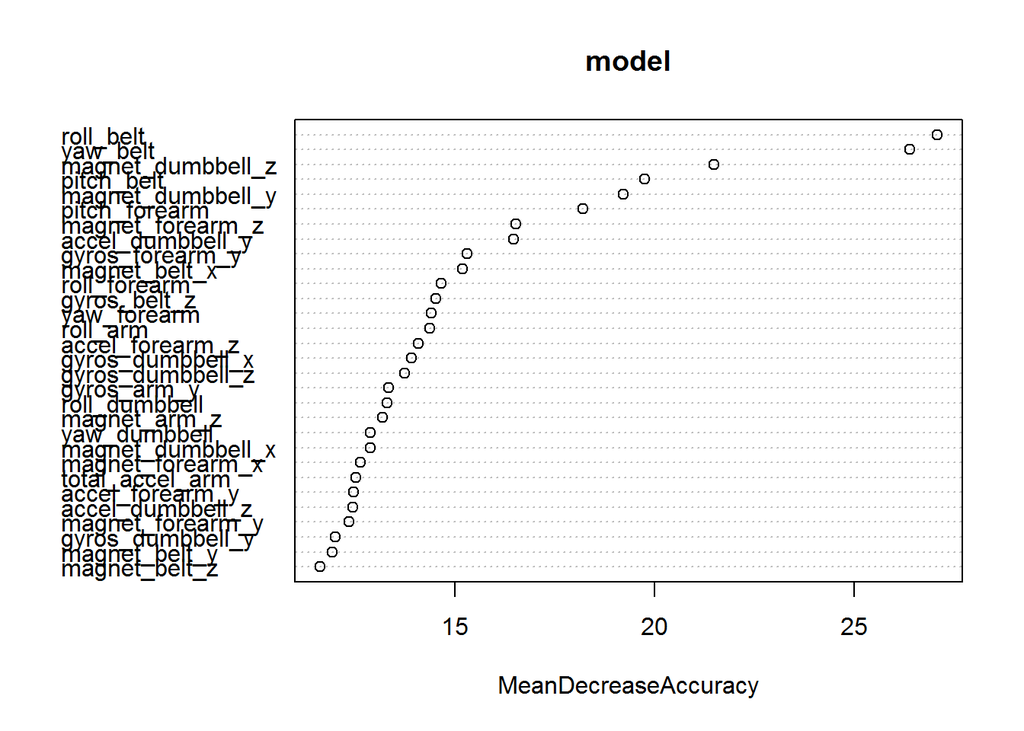

```r
varImpPlot(model, type=1)
```

This is very helpful because we can simplify our model to a newer one in where we just use the most influential variables in order to have smaller and faster decision trees.

## Prediction

Prediction will be performed using the “predict” function with model and testdata (20 cases to be predicted) as inputs:

```r
result <- predict(model, newdata=testdata)
result
```

```
##  1  2  3  4  5  6  7  8  9 10 11 12 13 14 15 16 17 18 19 20
##  B  A  B  A  A  E  D  B  A  A  B  C  B  A  E  E  A  B  B  B
## Levels: A B C D E
```

In order to submit result as text files to prediction assignment its necessary to use the next function and call:

```r
pml_write_files = function(x){
  n = length(x)
  for(i in 1:n){
    filename = paste0("problem_id_",i,".txt")
    write.table(x[i],file=filename,quote=FALSE,row.names=FALSE,col.names=FALSE)
  }
}
pml_write_files(result)
```

Results uploading give a 20/20 score, confirming the accuracy and quality of the model.